# GEOG 3023 Lab 3

Data Manipulation and Descriptive Statistics in R

Jason Lee

2022-09-20

Complete all 10 questions, and submit the finished Rmd and HTML files onto Canvas. Don’t forget to change name field in line 4 to your first and last name.

## Introduction

The dataframe is a key data structure in statistics and in R. The basic structure of a dataframe is that there is one observation per row and each column represents a variable, a measure, feature, or characteristic of that observation. R has an internal implementation of dataframes that is likely the one you will use most often. However, there are packages on CRAN that implement dataframes via things like relational databases that allow you to operate on very very large dataframes (but we won’t discuss them here).

Given the importance of managing dataframes, it’s important that we have good tools for dealing with them. Previously, we have already discussed some tools like the use of `[ , ]` and `$` operators to extract subsets of dataframes. However, other operations, like filtering, re-ordering, and collapsing, can often be tedious operations in R whose syntax is not very intuitive. The *dplyr* package (a part of the *tidyverse* package we’ve already been working in) is designed to mitigate a lot of these problems and to provide a highly optimized set of routines specifically for wrangling data in dataframes.

In this lab we explore commercial flights, specifically a random sample of domestic flights that departed from the three major New York City airport in 2013. We will generate simple graphical and numerical summaries of data on these flights and explore flight delay times. As this is a large dataset, along the way you’ll also learn the important skills of data processing and subsetting.

Chapters 10 and 13 of *R programming for Data Science* (freely avaiable: https://www.cs.upc.edu/~robert/teaching/estadistica/rprogramming.pdf) will be very helpful to this lab.

## Getting started

### Load packages

In this lab we will explore how to process data (e.g., subset) using the `tidyverse` (`dplyr`) package. The dataset we’ll be using is ‘nycflights.csv’.

Let’s load the packages and the dataset.

```r
library(tidyverse)
```

### Data

The [Bureau of Transportation Statistics](http://www.rita.dot.gov/bts/about/) (BTS) is a statistical agency that is a part of the Research and Innovative Technology Administration (RITA). As its name implies, BTS collects and makes available transportation data, such as the flights data we will be working with in this lab.

We begin by loading the `nycflights` dataframe. Run the following code chunk to load the data:

```r
# you might need to change to the correct folder
nycflights <- read.csv('data/nycflights.csv')
```

The dataframe containing 32735 flights that shows up in your workspace is a *data matrix*, with each row representing an *observation* and each column representing a *variable*. R calls this data format a **dataframe**, which is a term that will be used throughout the labs.

To view the names of the variables, type the command

```r
names(nycflights)
```

```
##  [1] "year"      "month"     "day"       "dep_time"  "dep_delay" "arr_time"
##  [7] "arr_delay" "carrier"   "tailnum"   "flight"    "origin"    "dest"
## [13] "air_time"  "distance"  "hour"      "minute"
```

This returns the names of the variables in this dataframe. The **codebook** (description of the variables) is included below. This information can also be found in the help file for the dataframe which can be accessed by typing `?nycflights` in the console.

- `year`: Year of departure
- `month`: Month of departure
- `day`: Day of departure
- `dep_time`: Departure times, 24-hr clock in local timezone.
- `arr_time`: Arrival times, 24-hr clock in local timezone.
- `dep_delay`: Departure delays, in minutes. Negative times represent early departures or arrivals.
- `arr_delay`: Arrival delays, in minutes. Negative times represent early departures or arrivals.
- `carrier`: Two letter carrier abbreviation.
  - `9E`: Endeavor Air Inc.
  - `AA`: American Airlines Inc.
  - `AS`: Alaska Airlines Inc.
  - `B6`: JetBlue Airways
  - `DL`: Delta Air Lines Inc.
  - `EV`: ExpressJet Airlines Inc.
  - `F9`: Frontier Airlines Inc.
  - `FL`: AirTran Airways Corporation
  - `HA`: Hawaiian Airlines Inc.
  - `MQ`: Envoy Air
  - `OO`: SkyWest Airlines Inc.
  - `UA`: United Air Lines Inc.
  - `US`: US Airways Inc.
  - `VX`: Virgin America
  - `WN`: Southwest Airlines Co.
  - `YV`: Mesa Airlines Inc.
- `tailnum`: Plane tail number
- `flight`: Flight number
- `origin`: Airport codes for flight origin. (Google can help you with what code stands for which airport.)
- `dest`: Airport codes for flight destination. (Google can help you with what code stands for which airport.)
- `air_time`: Amount of time spent in the air, in minutes.
- `distance`: Distance flown, in miles.
- `hour`, `minute`: Time of departure broken in to hour and minutes.

A very useful function for taking a quick peek at your dataframe, and viewing its dimensions and data types is `str`, which stands for `str`ucture.

```r
str(nycflights)
```

```
## 'data.frame':    32735 obs. of  16 variables:
##  $ year     : int  2013 2013 2013 2013 2013 2013 2013 2013 2013 2013 ...
##  $ month    : int  6 5 12 5 7 1 12 8 9 4 ...
##  $ day      : int  30 7 8 14 21 1 9 13 26 30 ...
##  $ dep_time : int  940 1657 859 1841 1102 1817 1259 1920 725 1323 ...
##  $ dep_delay: int  15 -3 -1 -4 -3 -3 14 85 -10 62 ...
##  $ arr_time : int  1216 2104 1238 2122 1230 2008 1617 2032 1027 1549 ...
##  $ arr_delay: int  -4 10 11 -34 -8 3 22 71 -8 60 ...
##  $ carrier  : chr  "VX" "DL" "DL" "DL" ...
##  $ tailnum  : chr  "N626VA" "N3760C" "N712TW" "N914DL" ...
##  $ flight   : int  407 329 422 2391 3652 353 1428 1407 2279 4162 ...
##  $ origin   : chr  "JFK" "JFK" "JFK" "JFK" ...
##  $ dest     : chr  "LAX" "SJU" "LAX" "TPA" ...
##  $ air_time : int  313 216 376 135 50 138 240 48 148 110 ...
##  $ distance : int  2475 1598 2475 1005 296 733 1411 228 1096 820 ...
##  $ hour     : int  9 16 8 18 11 18 12 19 7 13 ...
##  $ minute   : int  40 57 59 41 2 17 59 20 25 23 ...
```

Another useful function for taking a quick peek at your dataframe, and viewing its dimensions and data types is `head`, which stands for the `head` of the dataframe as it shows you the first 6 rows, unless more are specified.

```r
head(nycflights)
```

```
##   year month day dep_time dep_delay arr_time arr_delay carrier tailnum flight
## 1 2013     6  30      940        15     1216        -4      VX  N626VA    407
## 2 2013     5   7     1657        -3     2104        10      DL  N3760C    329
## 3 2013    12   8      859        -1     1238        11      DL  N712TW    422
## 4 2013     5  14     1841        -4     2122       -34      DL  N914DL   2391
## 5 2013     7  21     1102        -3     1230        -8      9E  N823AY   3652
## 6 2013     1   1     1817        -3     2008         3      AA  N3AXAA    353
##   origin dest air_time distance hour minute
## 1    JFK  LAX      313     2475    9     40
## 2    JFK  SJU      216     1598   16     57
## 3    JFK  LAX      376     2475    8     59
## 4    JFK  TPA      135     1005   18     41
## 5    LGA  ORF       50      296   11      2
## 6    LGA  ORD      138      733   18     17
```

The `nycflights` dataframe is a trove of information. Let’s think about some questions we might want to answer with these data:

- We might want to find out how often flights flying to a certain destination are delayed.
- We might want to evaluate how departure delays vary over months.
- Or we might want to determine which of the three major NYC airports has a better on time percentage for departing flights.

### Seven Functions + one operator

The `dplyr` package offers seven functions for basic data manipulation:

- `filter()`: extract a subset of rows from a dataframe based on logical conditions
- `arrange()`: reorder rows of a dataframe
- `select()`: return a subset of the columns of a dataframe, using a flexible notation
- `rename()`: rename variables in a dataframe
- `mutate()`: add new variables/columns or transform existing variables
- `summarise()`: generate summary statistics of different variables in the dataframe
- `group_by()`: define grouping variables to then perform another function on
- `%>%`: the “pipe” operator is used to connect multiple functions together into a pipeline

We will use some of these functions in this lab, and learn about others in future labs.

## Analysis

### Departure delays in flights to Denver (DEN)

We can examine the distribution of departure delays of all flights with a histogram.

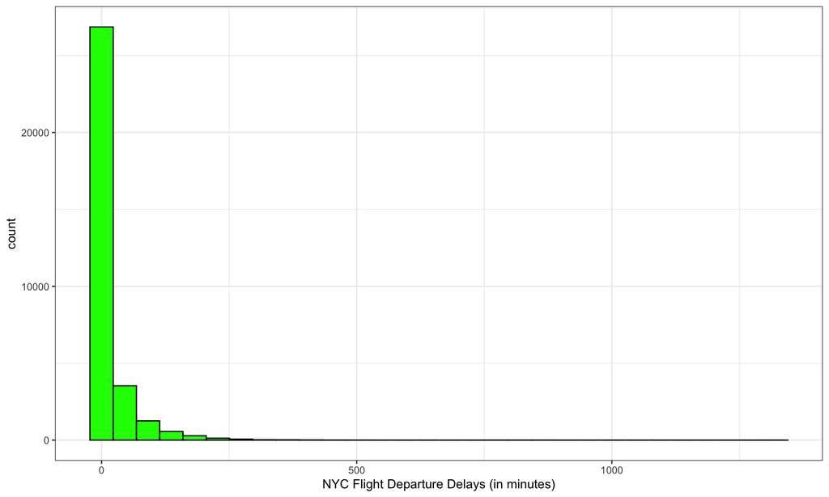

```r
ggplot(data=nycflights)+
  geom_histogram(aes(x=dep_delay),fill="green",color="black")+
  labs(x="NYC Flight Departure Delays (in minutes)",y="count")+
  theme_bw()
```

If we want to focus on departure delays of flights headed to Denver (DEN) only, we need to first `filter` the data for flights headed to DEN (`dest == "DEN"`) and then make a histogram of only departure delays of only those flights.

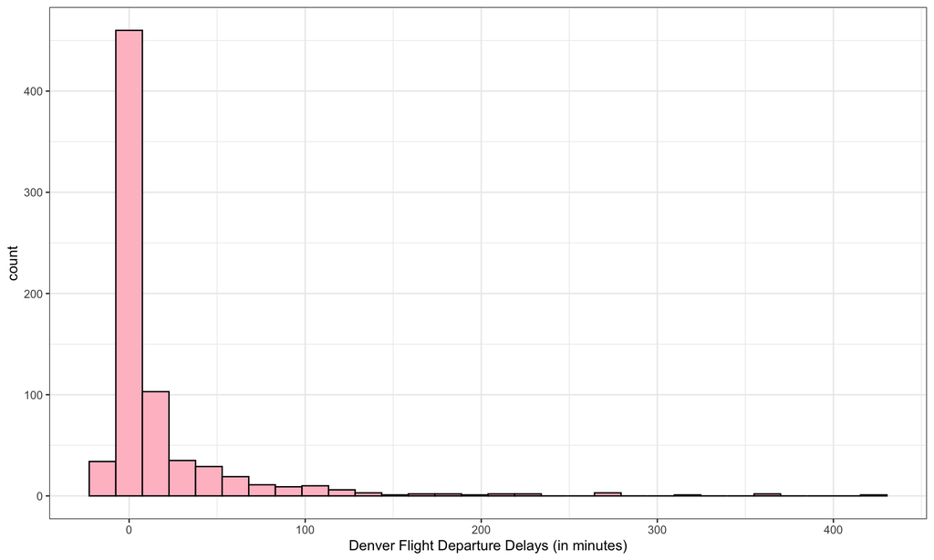

```r
den_flights <- nycflights %>%
  filter(dest == "DEN")

ggplot(data=den_flights)+
  geom_histogram(aes(x=dep_delay),fill="pink",color="black")+
  labs(x="Denver Flight Departure Delays (in minutes)",y="count")+
  theme_bw()
```

Let’s decipher the above three lines of code:

- Line 156-157: Take the `nycflights` dataframe, `filter` for flights headed to DEN, and save the result as a new dataframe called `den_flights`.
  - `==` means “if it’s equal to”.
  - `DEN` is in quotation marks since it is a character string.
- Line 159-162: Basically the same histogram as the previous code chunk, except that it uses the dataframe for flights headed to DEN instead of all flights.

If we don’t use the `filter()`function provided by *dplyr* package, we can alternatively use `subset()` or simply `[]` in base R functions for subsetting, but these two won’t be well integrated into *dplyr* workflow as it will be showed later.

```r
den_flights <- subset(nycflights, dest== "DEN")
den_flights2 <- nycflights[nycflights$dest=='DEN', ]
```

**Logical operators:** Filtering for certain observations (e.g. flights from a particular airport) is often of interest in dataframes where we might want to examine observations with certain characteristics separately from the rest of the data. To do so we use the `filter` function and a series of **logical operators**. The most commonly used logical operators for data analysis are as follows:

- `==` means “equal to”
- `!=` means “not equal to”
- `>` or `<` means “greater than” or “less than”
- `>=` or `<=` means “greater than or equal to” or “less than or equal to”

We can also obtain numerical summaries for these flights:

```r
den_flights %>%
  summarise(mean_dd = mean(dep_delay), sd_dd = sd(dep_delay), n = n())
```

```
##    mean_dd   sd_dd   n
## 1 16.28261 45.5349 736
```

Note that in the `summarise` function we created a list of two elements. The names of these elements are user defined, like `mean_dd`, `sd_dd`, `n`, and you could customize these names as you like (just don’t use spaces in your names). Calculating these summary statistics also require that you know the function calls. Note that `n()` reports the sample size.

**Summary statistics:** Some useful functions for summary statistics are below:

- `mean()`: mean of the data
- `median()`: median of the data
- `sd()`: standard deviation of the data
- `var()`: variance of the data
- `IQR()`: interquartile range of the data
- `range()`: range of the data
- `min()`: minimum of the data
- `max()`: maximum of the data

The function, `summary()`, is a handy function that prints the range, IQR, mean, and median of a dataset (a whole dataframe, specific columns in a dataframe, or a vector) all in one go.

We can also filter based on multiple criteria. Suppose we are interested in flights headed to San Francisco (SFO) in February:

```r
sfo_feb_flights <- nycflights %>%
  filter(dest == "SFO" & month == 2)
```

Note that we can separate the conditions using `&` if we want flights that are both headed to SFO **and** in February. If we are interested in either flights headed to SFO **or** in February we can use the `|` instead of the `&`.

**Q1: (4 pts)** Create a new dataframe, named `den_feb_flights`, that includes flights headed to Denver in February. How many flights meet these criteria? Hint: the number of rows (`nrows()`) in the datframe answers this question.

- 45
- 1345
- 2286
- 3563
- 32735

**Your answer:**

```r
# type your code for Question 1 here
# Hint: nrow()
den_feb_flights <- nycflights %>%
  filter(dest == "DEN" & month == 2)
nrow(den_feb_flights)
```

```
## [1] 45
```

**Q2 (4 pts)**: Using `ggplot`, make a histogram, properly label the axes, and calculate appropriate summary statistics for **arrival delays** of `den_feb_flights`. Which of the following is **false**?

- The distribution is unimodal.
- No flight is delayed more than an hour.
- The distribution is positively skewed.
- Flights most of arrive on time or earlier than scheduled.

**Your answer:**

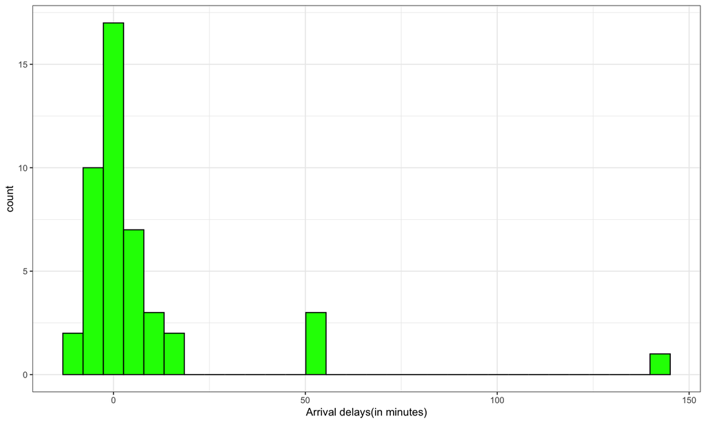

```r
# type your code for Question 2 here

ggplot()+
  geom_histogram(aes(x=den_feb_flights$dep_delay),fill="green", color="black")+
  labs(x="Arrival delays(in minutes)",y="count")+
  theme_bw()
```

```r
#'No flight is delayed more than an hour' is false.
```

Another useful functionality is being able to quickly calculate summary statistics for various groups in your dataframe. For example, we can modify the above command using the `group_by` function to get the same summary stats for each origin airport:

```r
den_flights %>%
  group_by(origin) %>%
  summarise(mean_dd = mean(dep_delay), sd_dd = sd(dep_delay), n = n())
```

```
## # A tibble: 3 × 4
##   origin mean_dd sd_dd     n
##   <chr>    <dbl> <dbl> <int>
## 1 EWR       17.6  43.5   263
## 2 JFK       31.7  57.7    81
## 3 LGA       12.2  43.4   392
```

Here, we first grouped the data by `origin`, and then calculated the summary statistics.

**Q3: (4 pts)** Calculate the interquartile range (IQR) for `arr_delay`s of flights in the `den_feb_flights` dataframe, grouped by carrier. Which carrier has the *lowest* IQR of arrival delays?

- American Airlines
- JetBlue Airways
- Virgin America
- Delta Airlines
- Southwest Airlines

**Your answer:**

```r
# type your code for Question 3 here
den_feb_flights %>%
  group_by(carrier) %>%
  summarize(med_ad = median(arr_delay), iqr_ad = IQR(arr_delay)) %>%
  arrange(desc(iqr_ad))
```

```
## # A tibble: 5 × 3
##   carrier med_ad iqr_ad
##   <chr>    <dbl>  <dbl>
## 1 WN       -15     36.5
## 2 B6        -9     24
## 3 UA        -2.5   16.2
## 4 F9        -7.5   13.2
## 5 DL       -20      7.5
```

```r
#Delta Air Lines Inc. has the lowest IQR.
```

### Departure delays over months

Which month would you expect to have the highest average delay departing from an NYC airport?

Let’s think about how we would answer this question:

- First, calculate monthly averages for departure delays. With the new language we are learning, we need to
  - `group_by` months, then
  - `summarise` mean departure delays.
- Then, we need to `arrange` these average delays in `desc`ending order

```r
nycflights %>%
  group_by(month) %>%
  summarise(mean_dd = mean(dep_delay)) %>%
  arrange(desc(mean_dd))
```

```
## # A tibble: 12 × 2
##    month mean_dd
##    <int>   <dbl>
##  1     7   20.8
##  2     6   20.4
##  3    12   17.4
##  4     4   14.6
##  5     3   13.5
##  6     5   13.3
##  7     8   12.6
##  8     2   10.7
##  9     1   10.2
## 10     9    6.87
## 11    11    6.10
## 12    10    5.88
```

**Q4: (6 pts)** Which month has the highest average departure delay from an NYC airport?

- January
- March
- July
- October
- December

**Your answer:**

```r
# type your code for Question 4 here

nycflights %>%
  group_by(month)%>%
  summarise(mean_dd = mean(dep_delay)) %>%
  arrange(desc(mean_dd))
```

```
## # A tibble: 12 × 2
##    month mean_dd
##    <int>   <dbl>
##  1     7   20.8
##  2     6   20.4
##  3    12   17.4
##  4     4   14.6
##  5     3   13.5
##  6     5   13.3
##  7     8   12.6
##  8     2   10.7
##  9     1   10.2
## 10     9    6.87
## 11    11    6.10
## 12    10    5.88
```

```r
#July has the highest average departure delay from an NYC airport.
```

**Q5: (6 pts)** Which month has the highest median departure delay from an NYC airport?

- January
- March
- July
- October
- December

**Your answer:**

```r
# type your code for Question 5 here

nycflights %>%
  group_by(month)%>%
  summarise(median_dd = median(dep_delay)) %>%
  arrange(desc(median_dd))
```

```
## # A tibble: 12 × 2
##    month median_dd
##    <int>     <dbl>
##  1    12         1
##  2     6         0
##  3     7         0
##  4     3        -1
##  5     5        -1
##  6     8        -1
##  7     1        -2
##  8     2        -2
##  9     4        -2
## 10    11        -2
## 11     9        -3
## 12    10        -3
```

```r
#December has the highest median departure delay from an NYC airport.
```

**Q6 (2 pts)** Is the mean or the median a more reliable measure for deciding which month(s) to avoid flying if you really dislike delayed flights, and why?

- Mean would be more reliable as it gives us the true average.
- Mean would be more reliable as the distribution of delays is symmetric.
- Median would be more reliable as the distribution of delays is skewed.
- Median would be more reliable as the distribution of delays is symmetric.
- Both give us useful information.

**You answer:**

We can also visualize the distributions of departure delays across months using side-by-side box plots:

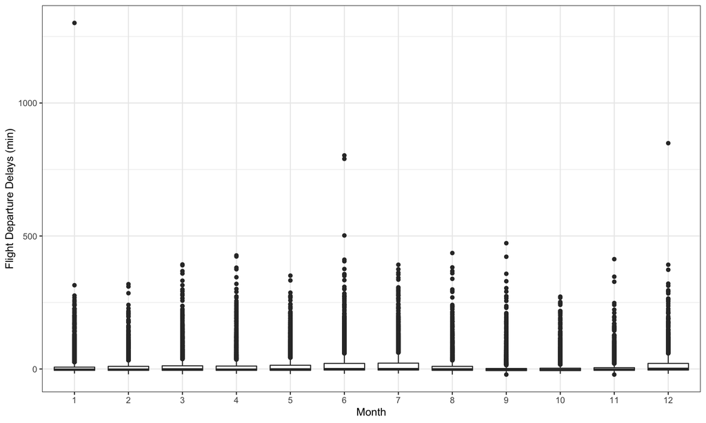

```r
ggplot(nycflights, aes(x = factor(month), y = dep_delay))+
  geom_boxplot()+
  labs(x="Month",y="Flight Departure Delays (min)")+
  theme_bw()
```

There is some new syntax here: We want departure delays on the y-axis and the months on the x-axis to produce side-by-side box plots. Side-by-side box plots require a categorical variable on the x-axis, however in the dataframe `month` is stored as a numerical variable (numbers 1 - 12). Therefore we can force R to treat this variable as categorical, what R calls a **factor**, variable with `factor(month)`.

### On time departure rate for NYC airports

Suppose you will be flying out of NYC and want to know which of the three major NYC airports has the best on time departure rate of departing flights. Suppose also that for you a flight that is delayed for less than 5 minutes is basically “on time”. You consider any flight delayed for 5 minutes of more to be “delayed”.

In order to determine which airport has the best on time departure rate, we need to

- first classify each flight as “on time” or “delayed”,
- then group flights by origin airport,
- then calculate on time departure rates for each origin airport,
- and finally arrange the airports in descending order for on time departure percentage.

Let’s start with classifying each flight as “on time” or “delayed” by creating a new variable with the `mutate` function.

```r
nycflights <- nycflights %>%
  mutate(dep_type = ifelse(dep_delay < 5, "on time", "delayed"))
```

The first argument in the `mutate` function is the name of the new variable we want to create, in this case `dep_type`. Then if `dep_delay < 5` we classify the flight as `"on time"` and `"delayed"` if not, i.e. if the flight is delayed for 5 or more minutes.

Note that we are also overwriting the `nycflights` dataframe with the new version of this dataframe that includes the new `dep_type` variable.

We can handle all the remaining steps in one code chunk:

```r
nycflights %>%
  group_by(origin) %>%
  summarise(ot_dep_rate = sum(dep_type == "on time") / n()) %>%
  arrange(desc(ot_dep_rate))
```

```
## # A tibble: 3 × 2
##   origin ot_dep_rate
##   <chr>        <dbl>
## 1 LGA          0.728
## 2 JFK          0.694
## 3 EWR          0.637
```

**Q7 (6 pts)** If you were selecting an airport to fly out of simply based on on time departure percentage (I.e., which airport has the highest percentage of on time departures), which NYC airport would you choose to fly out of?

- EWR
- JFK
- LGA

**Your answer:**

```r
# type your code for Question 7 here

nycflights %>%
  group_by(origin) %>%
  summarise(ot_dep_rate = sum(dep_type == "on time")/n()) %>%
  arrange(desc(ot_dep_rate))
```

```
## # A tibble: 3 × 2
##   origin ot_dep_rate
##   <chr>        <dbl>
## 1 LGA          0.728
## 2 JFK          0.694
## 3 EWR          0.637
```

```r
#Based on the on time departure percentage I will choose LGA to fly out.
```

**Q8: (6 pts)** Mutate the `nycflights` dataframe so that it includes a new variable (column) that contains the average speed, `avg_speed` traveled by the plane for each flight (in mph). What is the tail number of the plane with the fastest `avg_speed`? **Hint:** Average speed can be calculated as distance divided by number of hours of travel, and note that `air_time` is given in minutes. If you just want to show the `avg_speed` and `tailnum` and none of the other variables, use the select function at the end of your pipe to select just these two variables with `select(avg_speed, tailnum)`. You can Google this tail number to find out more about the aircraft.

- N666DN
- N755US
- N779JB
- N947UW
- N959UW

**Your answer:**

```r
# type your code for Question 8 here

nycflights <- nycflights %>%
  mutate(avg_speed = distance / (air_time/60))
nycflights %>%
  select(avg_speed, tailnum) %>%
  arrange(desc(avg_speed))
```

```
##       avg_speed tailnum
## 1      703.3846  N666DN
## 2      557.4419  N779JB
## 3      554.2197  N571JB
## 4      547.8857  N568JB
## 5      547.8857  N5EHAA
## 6      547.8857  N656JB
## 7      544.7727  N789JB
## 8      538.6517  N516JB
## 9      535.6425  N648JB
## 10     535.6425  N510JB
## 11     533.0387  N38268
## 12     533.0387  N53442
## 13     533.0387  N75858
## 14     532.6667  N624JB
```

[output cut: 32721 more lines]

```r
#N666DN
```

**Q9: (4 pts)** Using `ggplot()`, Make a scatter plot of `avg_speed` vs. `distance`, and correctly label your x- and y-axes with the name of the respective variable and it’s units. Which of the following is true about the relationship between average speed and distance.

- As distance increases the average speed of flights decreases.
- The relationship is linear.
- There is an overall positive association between distance and average speed.
- There are no outliers.
- The distribution of distances are uniform over 0 to 5000 miles.

**Your answer:**

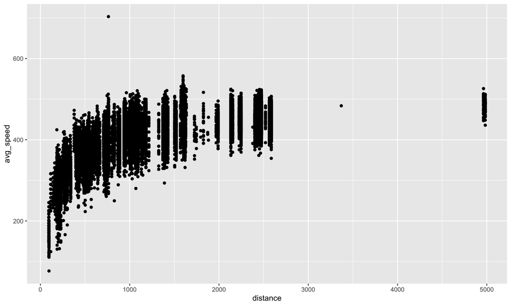

```r
# type your code for Question 9 here

ggplot(nycflights, aes(x = distance, y = avg_speed)) +
  geom_point()
```

**Q10: (10 pts)** Suppose you define a flight to be “on time” if it gets to the destination on time or earlier than expected, regardless of any departure delays. Mutate the data frame to create a new variable called `arr_type` with levels `"on time"` and `"delayed"` based on this definition. Also mutate to create a new variable called `dep_type` with levels `"on time"` and `"delayed"` depending on the flight was delayed for fewer than 5 minutes or 5 minutes or more, respectively. In other words, if `arr_delay` is 0 minutes or fewer, `arr_type` is `"on time"`. If `dep_delay` is less than 5 minutes, `dep_type` is `"on time"`. Then, determine the on time arrival percentage based on whether the flight departed on time or not. What percent of flights that were `"delayed"` departing arrive `"on time"`?

**Your answer:**

```r
# type your code for Question 10 here

nycflights %>%
  mutate(arr_type = ifelse(arr_delay <= 0, "on time", "delayed")) %>%
  mutate(dep_type = ifelse(dep_delay <= 0, "on time", "delayed")) %>%
  select(arr_type, dep_type) %>%
  table()
```

```
##          dep_type
## arr_type  delayed on time
##   delayed    9291    4171
##   on time    3508   15765
```

```r
3508/(3508+9291)
```

```
## [1] 0.2740839
```

#### 52 points total.

#### **Reminder** Did you put your name in line 4?

#### Once you’re all done with the lab, click the ‘knit’ button up at the top of this markdown window and submit both the .Rmd and .html files to Canvas.

#### Acknowledgements

This lab is a modified version of many previous labs created by many people. Thanks to Carson Farmer, Seth Spielman, Guofeng Cao, Adam Mahood, and Adam Reid.